# Where to open a new coffee shop in Denver?

## Hey! Welcome!

This was a data analysis competition hosted by DataCamp titled: *Where To Open A Coffee Shop?*

According to the competition, we were to act as data analysts for a client owning a coffee shop that sells high-quality and responsibly sourced coffee, pastries and sandwiches. They operate three locations in Fort Collins and want to expand into Denver. Your client believes that the ideal location for a new store is close to affluent households, and the store appeals to the 20-35 year old demographic.

The data was provided by the organizers and it included geographical and demographic information about Denver's neighborhoods. They also included data for Starbucks shops in Denver. Starbucks and the new coffee shops don't compete for the same clients; the team included their locations as a reference.

Let the games begin!

*Picture by Nathan Dumlao, Unsplash*

## Objectives:

- Visualizing Denver's neighborhoods and Starbucks store locations;
- Finding the neighborhoods with the highest proportion of people in the target demographic;
- Selecting top three neighborhoods where the client should focus their search.

## Inspecting and Cleaning The Data

### Starbucks_Denver

The *Starbucks* dataset had a considerable amount of missing values in the fifth and sixth columns (Street2, Street3). It also had geometric data that wasn't correctly classified as a geographical information object. Using *Geopandas*, the column containing the geographical locations of the stores was transformed into a Geopandas series, using the NAD83 datum.) coordinate system, a coordinate system that fits North America pretty well. The two columns with missing values were left without any modification because they contained a small amount of information that wasn't really beneficial to the analysis. The table below is a preview of the resulting table:

|  | StoreNumber | Name | PhoneNumber | Street1 | Street2 | Street3 | PostalCode | Longitude | Latitude | geometry |
| --- | --- | --- | --- | --- | --- | --- | --- | --- | --- | --- |
| 0 | 27708-240564 | Auraria Tivoli - Student Union | 3035563700 | 900 Auraria Parkway | NaN | NaN | 80204 | -105.01 | 39.75 | POINT (-105.01000 39.75000) |
| 1 | 75828-94910 | Grand Hyatt Denver | 303-295-1234 | 1740 Welton St | NaN | NaN | 802023940 | -104.99 | 39.75 | POINT (-104.99000 39.75000) |
| 2 | 74105-23807 | Safeway - Denver #1463 | 303-722-6117 | 2150 S Downing | NaN | NaN | 802104528 | -104.97 | 39.68 | POINT (-104.97000 39.68000) |
| 3 | 22871-102491 | Safeway - Denver #1248 | 303-477-5091 | 2660 Federal Blvd | NaN | NaN | 80211 | -105.02 | 39.76 | POINT (-105.02000 39.76000) |
| 4 | 11105-100844 | Highlands Garden Village | 303-455-3382 | 4500 W 38th Ave | NaN | NaN | 802122001 | -105.05 | 39.77 | POINT (-105.05000 39.77000) |

### Neighborhoods

The Coordinate Reference System (CRS) of the *neighborhoods* displayed *"None"* when I printed it out. I thus set it to NAD83, the same one I used for the Starbucks dataset. Apart from this, the dataset was fine and ready to go.

|  | NBHD_ID | NBHD_NAME | geometry |
| --- | --- | --- | --- |
| 0 | 2 | Auraria | POLYGON ((-105.00042 39.74552, -105.00041 39.7... |
| 1 | 21 | Cory - Merrill | POLYGON ((-104.94070 39.69540, -104.94070 39.6... |
| 2 | 7 | Belcaro | POLYGON ((-104.94070 39.71156, -104.94069 39.7... |
| 3 | 70 | Washington Park | POLYGON ((-104.95931 39.71566, -104.95931 39.7... |
| 4 | 71 | Washington Park West | POLYGON ((-104.97342 39.68982, -104.97356 39.6... |

### Census Data

38.4% of neighborhoods (30 out of 78) in the census data had missing values on the 'NUM_HHLD_100K+' column, a column key to the analysis. According to statistical theory, this is too much to let go. The best way is to impute, that is, to fill-in the missing values based on a mathematical guess on what they could be. I did this by using both the KNN and MICE methods of the *FancyImpute* package, and then evaluated the accuracy of their estimation against the linear model of neighborhoods which didn't have missing values. *MICE* imputation seems to win the fight, with an adjusted Rsquare of 0.809, higher than that of the complete cases. It contained 77 neighborhoods, one less from the original 78 because it contained a wrong value for the 'NUM_HHLD_100K+' column. (*Auraria; had an estimated number of households with income above 100k as 72 while there were only 60 households in the neighborhoods overall!*).

```
Imputing row 1/78 with 0 missing, elapsed time: 0.003
```

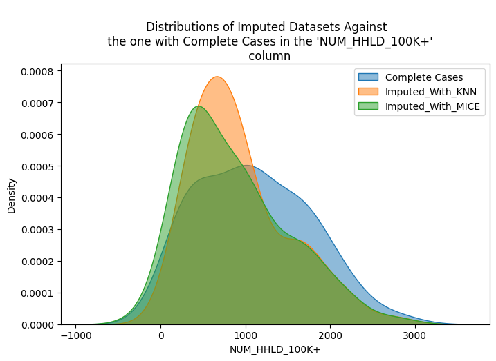

|  | Complete_Cases | KNN_Imputed | MICE_Imputed |
| --- | --- | --- | --- |
| Adj. Rsquared | 0.726239 | 0.717802 | 0.809856 |
| const | 20.973212 | 222.004578 | 52.264866 |
| POPULATION_2010 | 0.037421 | -0.016575 | 0.028680 |
| AGE_LESS_18 | -0.577000 | -0.484689 | -0.563336 |
| AGE_18_TO_34 | -0.054079 | -0.016112 | -0.050287 |
| AGE_35_TO_65 | 0.842184 | 0.698854 | 0.824434 |
| AGE_65_PLUS | -0.173683 | -0.214628 | -0.182131 |
| NUM_HOUSEHOLDS | -0.238193 | -0.156292 | -0.225860 |
| FAMILIES | 0.092161 | 0.216775 | 0.111285 |

|  | NBHD_NAME | POPULATION_2010 | AGE_LESS_18 | AGE_18_TO_34 | AGE_35_TO_65 | AGE_65_PLUS | NUM_HOUSEHOLDS | FAMILIES | NUM_HHLD_100K+ |
| --- | --- | --- | --- | --- | --- | --- | --- | --- | --- |
| 0 | Athmar Park | 8898 | 2649 | 2406 | 3112 | 731 | 2781 | 1964 | 425 |
| 2 | Baker | 4879 | 745 | 1762 | 2037 | 335 | 2447 | 833 | 832 |
| 3 | Barnum | 6111 | 2015 | 1647 | 2089 | 360 | 1782 | 1289 | 120 |
| 4 | Barnum West | 5376 | 1579 | 1380 | 1824 | 593 | 1704 | 1207 | 400 |
| 5 | Bear Valley | 8889 | 2036 | 2375 | 3190 | 1288 | 3652 | 2285 | 862 |
| ... | ... | ... | ... | ... | ... | ... | ... | ... | ... |
| 73 | West Colfax | 9740 | 2756 | 2935 | 3111 | 938 | 3703 | 1971 | 431 |
| 74 | West Highland | 8540 | 1304 | 2555 | 3756 | 925 | 4256 | 1853 | 1725 |
| 75 | Westwood | 15486 | 5678 | 4037 | 4712 | 1059 | 4340 | 3306 | 326 |
| 76 | Whittier | 4831 | 1119 | 1586 | 1788 | 338 | 1993 | 1008 | 559 |
| 77 | Windsor | 12589 | 1819 | 3302 | 4085 | 3383 | 7204 | 2590 | 723 |

77 rows × 9 columns

## Exploratory Data Analysis

### Where are Starbucks Stores?

- It seems Starbucks go for moderately populated areas. Plotting the location of their stores against a population density map shows that most stores are located in areas with between 2,107 to 4,203 people per square kilometer. Only one store is in a densely populated neighborhood (Capitol Hill).

|  | NBHD_ID | NBHD_NAME | geometry | POPULATION_2010 | AGE_LESS_18 | AGE_18_TO_34 | AGE_35_TO_65 | AGE_65_PLUS | NUM_HOUSEHOLDS | FAMILIES | NUM_HHLD_100K+ | Area | DENSITY | DENSITY_SCALED | Probs | Spatial Probs (%) |
| --- | --- | --- | --- | --- | --- | --- | --- | --- | --- | --- | --- | --- | --- | --- | --- | --- |
| 0 | 1 | Athmar Park | POLYGON ((-104.99238 39.69666, -104.99295 39.6... | 8898 | 2649 | 2406 | 3112 | 731 | 2781 | 1964 | 425 | 4.0032 | 2223.0 | 0.263836 | 4.132294 | 1.032247 |

Make this Notebook Trusted to load map: File -> Trust Notebook

[interactive chart not shown]

- They also seem to be located in neighborhoods with a small number of households and families. The two maps below show that most Starbucks stores are found in neighborhoods with between 2185 to 3919 households and 222 to 1361 families, a pretty low number when put to scale for all neighborhoods.

Make this Notebook Trusted to load map: File -> Trust Notebook

[interactive chart not shown]

Make this Notebook Trusted to load map: File -> Trust Notebook

[interactive chart not shown]

- Looking at their location in relation to affluence, that is, the number of households with income above 100K+ in a neighborhood, it seems that starbucks targets a little above moderate affluent neighborhoods, with a small number of families and households and a population that isn't that dense.

Looking at this outcome, one can't help but guess that most starbucks are located in downtown neighborhoods, with a lot of businesses / institutions (schools, tuition centers etc) where only a little bit over an average number of affluent families live.

Make this Notebook Trusted to load map: File -> Trust Notebook

[interactive chart not shown]

### Where is our targeted population?

Make this Notebook Trusted to load map: File -> Trust Notebook

[interactive chart not shown]

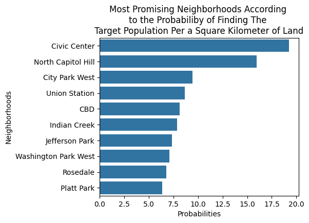

## Recommendations

- Our client should focus on Civic Center if the objective is to start with one or two shops.
- North Capitol Hill and City Park West are the next best options.
- Because of their sizes, the optimal number of stores that could be opened in each of these three neighborhoods is 1 and the maximum is 2.

## Documentations

#### Starbucks locations in Denver, Colorado

- "StoreNumber" - Store Number as assigned by Starbucks
- "Name" - Name identifier for the store
- "PhoneNumber" - Phone number for the store
- "Street 1, 2, and 3" - Address for the store
- "PostalCode" - Zip code of the store
- "Longitude, Latitude" - Coordinates of the store

#### Neighborhoods' geographical information

- "NBHD_ID" - Neighborhood ID (matches the census information)
- "NBHD_NAME" - Name of the statistical neighborhood
- "Geometry" - Polygon that defines the neighborhood

#### Demographic information

- "NBHD_ID" - Neighborhood ID (matches the geographical information)
- "NBHD_NAME' - Nieghborhood name
- "POPULATION_2010' - Population in 2010
- "AGE_ " - Number of people in each age bracket (< 18, 18-34, 35-65, and > 65)
- "NUM_HOUSEHOLDS" - Number of households in the neighborhood
- "FAMILIES" - Number of families in the neighborhood
- "NUM_HHLD_100K+" - Number of households with income above 100 thousand USD per year

*Starbucks locations were scrapped from the Starbucks store locator webpage by [Chris Meller](https://github.com/chrismeller/).*  
*Statistical Neighborhood information from the [City of Denver Open Data Catalog](http://data.denvergov.org), [CC BY 3.0](http://creativecommons.org/licenses/by/3.0/) license.*  
*Census information from the [United States Census Bureau](https://www.census.gov/). Publicly available information.*

*Notebook prepared by Muhammad-David Mukajanga*

*For similar projects, check out my website: mukajangadavid.com*

[output not shown]